# Taller 2 Análisis Estadístico de Datos

2023-02-24

## Integrantes

- Diryon Yonith Mora Romero
- Fabio Andrés Rizo Montoya
- Laura Valentina González Rodríguez

## Funciones y librerias

```r
library(plot3D)
library(rgl)
library(Matrix)

# Population
covariance_matrix <- function(x){
  tamamio = c(nrow(x),ncol(x))
  cova <- matrix(0,nrow = tamamio[2], ncol = tamamio[2]);cova
  x_var = colMeans(x)
  for (i in 1:tamamio[2]){
    for ( j in 1:tamamio[2]){
      sum = 0
      for (k in 1:tamamio[1]){
        sum = sum + (x[k,i]-x_var[i])*(x[k,j]-x_var[j])
      }
      cova[i,j] = sum / tamamio[1]
    }
  }
  return(cova)
}
# Sample
variance_sample <- function(x){
  return(cov(x))
}

des_espectral <- function(A){
  ro = nrow(A);  lambda <- eigen(A);
  n = length(lambda);
  Result = 0;
  for (i in 1:n) {
    print(sprintf("El %d valor propio de la matriz es: %g", i, lambda$values[i]))
    vect_pro <- matrix(c(lambda$vectors[,i]), nrow = ro, ncol = 1);
    print(sprintf("El vector propio es %s.", toString(vect_pro)))
    print(sprintf("Obteniendo la matriz %d :", i))
    Opera = lambda$values[i]*vect_pro%*%t(vect_pro);
    print(Opera)
    Result = Result + Opera;
  }
  print("El resultado de sumar las matrices x' es:")
  print(Result)
  return(Result)
}

Lengt <- function(x){
  n = length(x);
  value = 0;
  for( i in 1:n){
    value = value + (x[i])^2;
  }
  return(sqrt(value))
}

dd_dot <- function(x,y){
  return(x%*%y)
}

# Installar sympy en la terminal de RStudio
# pip3 install sympy

py_install(packages = c("sympy"), pip = TRUE)
```

## Punto 1

Dadas las 5 medidas sobre las variables $x_1$, $x_2$ y $x_3$.

```r
x1= c(9,2,6,5,8);
x2= c(12,8,6,4,10);
x3=c(3,4,0,2,1);
X <- cbind(x1,x2,x3);
kable(X)
```

| x1 | x2 | x3 |
| --- | --- | --- |
| 9 | 12 | 3 |
| 2 | 8 | 4 |
| 6 | 6 | 0 |
| 5 | 4 | 2 |
| 8 | 10 | 1 |

La matriz $\bar{X}$ es:

```r
colMeans <- colMeans(X);
kable(colMeans)
```

|  | x |
| --- | --- |
| x1 | 6 |
| x2 | 8 |
| x3 | 2 |

La matriz $S_n$ es:

```r
S = covariance_matrix(X);
kable(S)
```

| 6.0 | 4.0 | -1.4 |
| --- | --- | --- |
| 4.0 | 8.0 | 1.2 |
| -1.4 | 1.2 | 2.0 |

```r
cov(S)
```

```
##          [,1]  [,2]  [,3]
## [1,] 14.65333  8.24 -5.78
## [2,]  8.24000 11.68 -0.76
## [3,] -5.78000 -0.76  3.16
```

La matriz $R$ es:

```r
Correlation = cor(X);
kable(Correlation)
```

|  | x1 | x2 | x3 |
| --- | --- | --- | --- |
| x1 | 1.0000000 | 0.5773503 | -0.4041452 |
| x2 | 0.5773503 | 1.0000000 | 0.3000000 |
| x3 | -0.4041452 | 0.3000000 | 1.0000000 |

## Punto 2

Sea $x'=[5, 1, 3]$ y $y'=[-1, 3, 1]$.

### Punto 2.a)

Grafique los dos vectores.

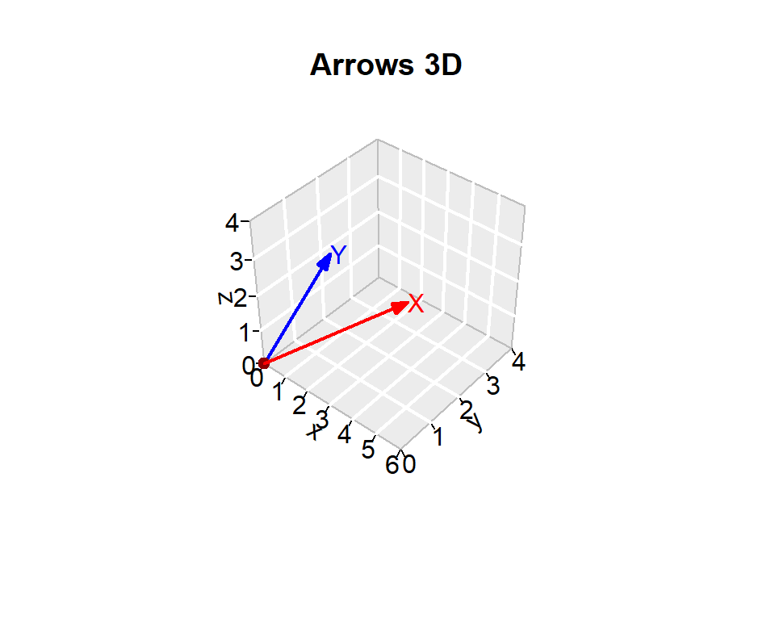

```r
x <- c(5, 1, 3)
y <- c(-1, 3, 1)
origin <- c(0,0,0)

x0 = c(0, 0)
y0 = c(0, 0)
z0 = c(0, 0)
cols <- c('red','blue')

x1 = c(5, -1)
y1 = c(1, 3)
z1 = c(3, 1)

arrows3D(x0, y0, z0, x1, y1, z1,  col = cols, lwd = 2, d = 5,
         main = "Arrows 3D", bty ="g", ticktype = "detailed", xlim = c(0,6),
         ylim = c(0,4), zlim = c(0,4))
points3D(x0, y0, z0, add = TRUE, col="darkred",
         colkey = FALSE, pch = 19, cex = 1)
text3D(x1, y1, z1, c("X", "Y"), colvar = NULL, col = cols, add=TRUE, colkey = FALSE)
```

### Punto 2.b)

Encontrar:

#### Punto 2.b.i)

La longitud de x.

```r
Lx = Lengt(x);Lx
```

```
## [1] 5.91608
```

#### Punto 2.b.ii)

El ángulo entre $x$ y $y$.

```r
Ly = Lengt(y);
x_y = x1[1]*x1[2]+y1[1]*y1[2]+z1[1]*z1[2];
theta = acos(x_y/(Lx*Ly))*180/pi;theta
```

```
## [1] 87.07867
```

#### Punto 2.b.iii)

La proyección de y en x.

```r
x_com<-c(5,1,3)
Pro_y_x = (x_y*x_com)/(Lx*Lx);Pro_y_x
```

```
## [1] 0.14285714 0.02857143 0.08571429
```

### Punto 2.c)

Dado que $\bar{x}=3$ y $\bar{y}=1$. Grafique $x'=[2,-2,0]$ y $y'=[-2,2,0]$

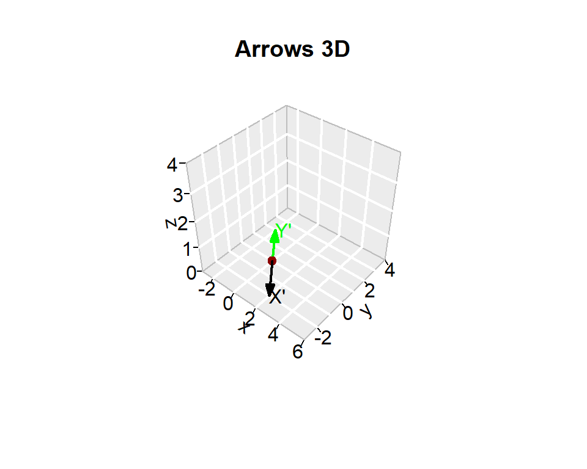

```r
x1 = c(2, -2)
y1 = c(-2, 2)
z1 = c(0, 0)
x0 = c(0, 0)
y0 = c(0, 0)
z0 = c(0, 0)

cols <- c('black','green')

arrows3D(x0, y0, z0, x1, y1, z1,  col = cols, lwd = 2, d = 3,
         main = "Arrows 3D", bty ="g", ticktype = "detailed", xlim = c(-3,6),
         ylim = c(-3,4), zlim = c(0,4))
points3D(x0, y0, z0, add = TRUE, col="darkred",
         colkey = FALSE, pch = 19, cex = 1)
text3D(x1, y1, z1, c("X'", "Y'"), colvar = NULL, col = cols, add=TRUE, colkey = FALSE)
```

## Punto 3

Dada la matriz

```r
A <- rbind(c(9,-2),c(-2,6));A
```

```
##      [,1] [,2]
## [1,]    9   -2
## [2,]   -2    6
```

### Punto 3.a)

¿Es $A$ una matriz simétrica?

```r
A_tran <- t(A);
kable(A_tran);
```

| 9 | -2 |
| --- | --- |
| -2 | 6 |

Como se puede observar la matriz es la misma respecto a su transpuesta, por lo tanto es simetrica.

### Punto 3.b)

Muestre que $A$ es definida positiva.

Una matriz es definida positiva, Si todos los autovalores son positivos, la matriz es definida positivamente. Si hay autovalores negativos o cero, la matriz no es definida positivamente.

```r
lambda <- eigen(A);
lambda$values;
```

```
## [1] 10  5
```

Note que todos sus autovalores son positivos, por lo tanto es definida positivamente.

### Punto 3.c)

Determine los valores y vectores propios de $A$.

```r
eig<- eigen(A)
eig$values
```

```
## [1] 10  5
```

```r
eig$vectors
```

```
##            [,1]       [,2]
## [1,] -0.8944272 -0.4472136
## [2,]  0.4472136 -0.8944272
```

### Punto 3.d)

Encuentre la descomposición espectral de $A$.

```r
des_a = des_espectral(A);
```

```
## [1] "El 1 valor propio de la matriz es: 10"
## [1] "El vector propio es -0.894427190999916, 0.447213595499958."
## [1] "Obteniendo la matriz 1 :"
##      [,1] [,2]
## [1,]    8   -4
## [2,]   -4    2
## [1] "El 2 valor propio de la matriz es: 5"
## [1] "El vector propio es -0.447213595499958, -0.894427190999916."
## [1] "Obteniendo la matriz 2 :"
##      [,1] [,2]
## [1,]    1    2
## [2,]    2    4
## [1] "El resultado de sumar las matrices x' es:"
##      [,1] [,2]
## [1,]    9   -2
## [2,]   -2    6
```

### Punto 3.e)

Determine la inversa de $A$.

```r
A_in <- solve(A);
kable(A_in);
```

| 0.12 | 0.04 |
| --- | --- |
| 0.04 | 0.18 |

### Punto 3.f)

Descomposicion de $A^{-1}$.

```r
Des_E=des_espectral(A_in);
```

```
## [1] "El 1 valor propio de la matriz es: 0.2"
## [1] "El vector propio es 0.447213595499958, 0.894427190999916."
## [1] "Obteniendo la matriz 1 :"
##      [,1] [,2]
## [1,] 0.04 0.08
## [2,] 0.08 0.16
## [1] "El 2 valor propio de la matriz es: 0.1"
## [1] "El vector propio es -0.894427190999916, 0.447213595499958."
## [1] "Obteniendo la matriz 2 :"
##       [,1]  [,2]
## [1,]  0.08 -0.04
## [2,] -0.04  0.02
## [1] "El resultado de sumar las matrices x' es:"
##      [,1] [,2]
## [1,] 0.12 0.04
## [2,] 0.04 0.18
```

## Punto 4

Verificar la relaciones $V^{1/2} \rho V^{1/2} = \Sigma$ y $\rho = (V^{1/2})^{-1} \Sigma (V^{1/2})^{-1}$, donde $\Sigma$ es el $p \times p$ matriz de covarianza poblacional, $\rho$ es la matriz de correlación poblacional $p \times p$ y $V^{1/2}$ es la matriz de desviación estándar de la población.

Para verificar la relación $V^{1/2} \rho V^{1/2} = \Sigma$, necesitamos demostrar que ambos lados de la ecuación son iguales.

Comencemos con el lado izquierdo: $V^{1/2} \rho V^{} = (V^{1/2} \rho) (V^{1/2}) = (V^{1/2} (\rho V^{1/2}))$ … (asociatividad de la multiplicación de matrices) $= (V^{1/2} (V^{-1/2} \Sigma V^{-1/2}) V^{1/2})$ … (definición de $\rho$ en términos de $\Sigma$ y $V^{-1/2}$) $= \Sigma$

Por lo tanto, hemos demostrado que $V^{1/2} \rho V^{1/2} = \Sigma$.

Para demostrar que $\rho = (V^{1/2})^{-1} \Sigma (V^{1/2})^{-1}$, comencemos con el lado derecho: $(V^{1/2})^{-1} \Sigma (V^{1/2})^{-1} = (V^{-1/2} V^{1/2})^T \Sigma (V^{-1/2} V^{1/2})^T$ … (propiedad de la inversa de una matriz) $= (V^{1/2})^T (V^{-1})^T \Sigma V^{-1/2} V^{1/2}$ … (propiedad de la traspuesta) $= V^{1/2} \Sigma V^{-1} V^{-1/2}$ … (propiedad de la inversa de una matriz) $= V^{1/2} (V^{-1/2} \rho V^{-1/2}) V^{1/2}$ … (definición de $\Sigma$ en términos de $\rho$ y $V^{-1/2}$) $= \rho$

Por lo tanto, hemos demostrado que $\rho = (V^{1/2})^{-1} \Sigma (V^{1/2})^{-1}$.

## Punto 5

Derive las expresiones para la media y las varianzas de las siguientes combinaciones lineales en términos de las medias y covarianzas de las variables aleatorias $X_1$, $X_2$ y $X_3$.

Para las siguientes combinaciones lineales de variables aleatorias, utilizaremos las siguientes propiedades de la esperanza y la varianza:

- Linealidad de la esperanza: $E(aX + bY) = aE(X) + bE(Y)$, donde $a$ y $b$ son constantes.
- Propiedades de la covarianza: $\text{Cov}(X,Y) = E(XY) - E(X)E(Y)$, $\text{Cov}(X,X) = \text{Var}(X)$.
- $X_1 - 2X_2$:
  - Media: $E(X_1 - 2X_2) = E(X_1) - 2E(X_2)$
  - Varianza: $\text{Var}(X_1 - 2X_2) = \text{Var}(X_1) + 4\text{Var}(X_2) - 4\text{Cov}(X_1,X_2)$
- $-X_1 + 3X_2$:
  - Media: $E(-X_1 + 3X_2) = -E(X_1) + 3E(X_2)$
  - Varianza: $\text{Var}(-X_1 + 3X_2) = \text{Var}(X_1) + 9\text{Var}(X_2) - 6\text{Cov}(X_1,X_2)$
- $X_1 + X_2 + X_3$:
  - Media: $E(X_1 + X_2 + X_3) = E(X_1) + E(X_2) + E(X_3)$
  - Varianza: $\text{Var}(X_1 + X_2 + X_3) = \text{Var}(X_1) + \text{Var}(X_2) + \text{Var}(X_3) + 2[\text{Cov}(X_1,X_2) + \text{Cov}(X_1,X_3) + \text{Cov}(X_2,X_3)]$
- $X_1 + 2X_2 - X_3$:
  - Media: $E(X_1 + 2X_2 - X_3) = E(X_1) + 2E(X_2) - E(X_3)$
  - Varianza: $\text{Var}(X_1 + 2X_2 - X_3) = \text{Var}(X_1) + 4\text{Var}(X_2) + \text{Var}(X_3) - 4[\text{Cov}(X_1,X_2) + \text{Cov}(X_1,X_3) + \text{Cov}(X_2,X_3)]$
- $3X_1 - 4X_2$ (si $X_1$ y $X_2$ son variables aleatorias independientes):
  - Media: $E(3X_1 - 4X_2) = 3E(X_1) - 4E(X_2)$
  - Varianza: $Var(3X_1 - 4X_2) = 9Var(X_1) + 16Var(X_2)$

## Punto 6

Dada la matriz de datos

```r
x <- cbind(c(4,-1,3),c(1,3,5));x
```

```
##      [,1] [,2]
## [1,]    4    1
## [2,]   -1    3
## [3,]    3    5
```

### Punto 6.a)

Grafique el diagrama de dispersión en p = 2 dimensiones. Localice la media de la muestra en su diagrama.

```r
means <- colMeans(x);means
```

```
## [1] 2 3
```

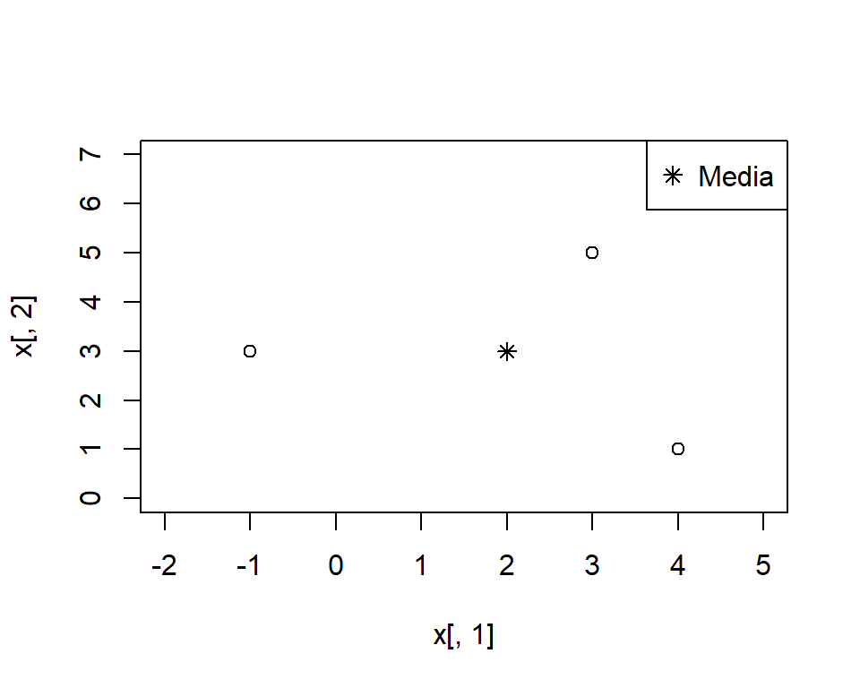

```r
plot(x = x[,1], y = x[,2], xlim = c(-2,5), ylim = c(-0,7))
points(means[1],means[2], pch=8)
legend("topright", legend = c("Media"), pch = c(8))
```

### Punto 6.b)

Dibuje la representación n = 3 -dimensional de los datos y trace los vectores de desviación $y_1-\bar{x}_11$ y $y_2-\bar{x}_21$.

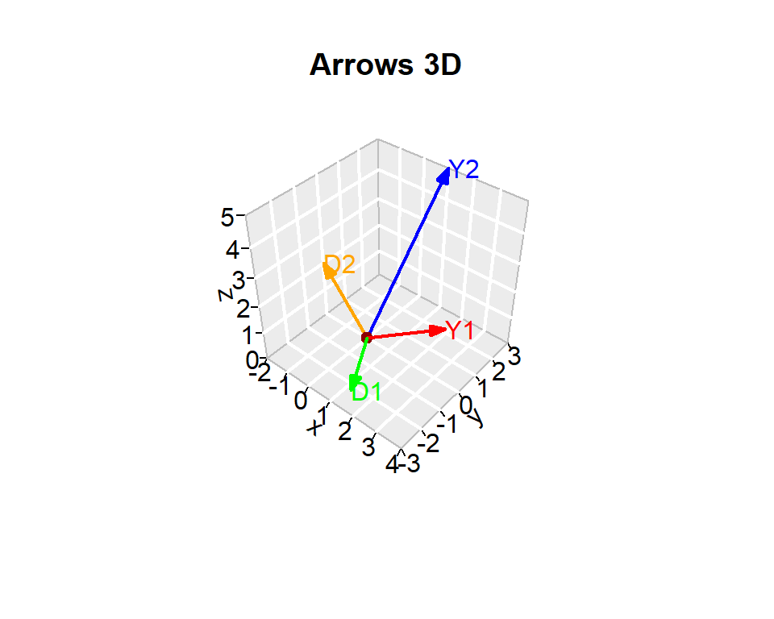

```r
x_t = t(x);
d1 = x_t[1,] - means[1]*c(1,1,1);
d2 = x_t[2,] - means[2]*c(1,1,1);
x1 = c(x_t[1,1],x_t[2,1],d1[1],d2[1]);
y1 = c(x_t[1,2],x_t[2,2],d1[2],d2[2]);
z1 = c(x_t[1,3],x_t[2,3],d1[3],d2[3]);
x0 = c(0, 0, 0, 0);
y0 = c(0, 0, 0, 0);
z0 = c(0, 0, 0, 0);
cols <- c('red','blue','green','orange')
arrows3D(x0, y0, z0, x1, y1, z1,  col = cols,
         lwd = 2, d = 3,  main = "Arrows 3D", bty ="g", ticktype = "detailed")
points3D(x0, y0, z0, add = TRUE, col="darkred",
         colkey = FALSE, pch = 19, cex = 1)
text3D(x1, y1, z1, c("Y1","Y2","D1","D2"), colvar = NULL, col = cols, add=TRUE, colkey = FALSE)
```

### Punto 6.c)

Dibuje los vectores de desviación en (b) que emanan del origen.

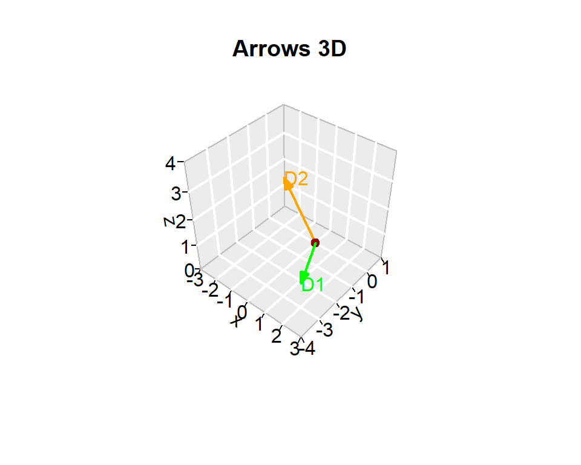

```r
x1 = c(d1[1],d2[1]);
y1 = c(d1[2],d2[2]);
z1 = c(d1[3],d2[3]);
x0 = c(0, 0);
y0 = c(0, 0);
z0 = c(0, 0);
cols <- c('green','orange')
arrows3D(x0, y0, z0, x1, y1, z1,  col = cols,
         lwd = 2, d = 3,  main = "Arrows 3D", bty ="g", ticktype = "detailed",
         xlim = c(-3,3), ylim = c(-4,1),zlim=c(0,4))
points3D(x0, y0, z0, add = TRUE, col="darkred",
         colkey = FALSE, pch = 19, cex = 1)
text3D(x1, y1, z1, c("D1","D2"), colvar = NULL, col = cols, add=TRUE, colkey = FALSE)
```

Calcula las longitudes de estos vectores y el coseno del ángulo entre ellos.

```r
Ld1= Lengt(d1); Ld1
```

```
## [1] 3.741657
```

```r
Ld2 = Lengt(d2); Ld2
```

```
## [1] 2.828427
```

```r
d1_d2 = x1[1]*x1[2]+y1[1]*y1[2]+z1[1]*z1[2];
cos_theta = d1_d2/(Ld1*Ld2);cos_theta
```

```
## [1] -0.1889822
```

Relacione estas cantidades con $S_n$ y $R$.

Note que $d_x'dy = n \cdot s_{xy}$, donde $n$ es la dimensionalidad de las variables. Por lo cuál al realizar todas las conbinaciones posibles de la matriz $n \times n$ y dividirlas por la $n$-dimensionalidad, se obtentra la misma matriz de varianzas y covarianzas.

```r
dd11 = dd_dot(d1,d1);
dd12 = dd_dot(d1,d2);
dd21 = dd_dot(d2,d1);
dd22 = dd_dot(d2,d2);
s11 =  dd11/3;
s12 =  dd12/3;
s21 =  dd21/3;
s22 =  dd22/3;
vars <- rbind(c(s11,s12),c(s21,s22));vars
```

```
##            [,1]       [,2]
## [1,]  4.6666667 -0.6666667
## [2,] -0.6666667  2.6666667
```

Note que esta matriz es la misma que la matriz de varianzas y covarianzas.

```r
covariance_matrix(x)
```

```
##            [,1]       [,2]
## [1,]  4.6666667 -0.6666667
## [2,] -0.6666667  2.6666667
```

Adicionalmente, sabemos que $r_{xy}=\frac{s_{xy}}{\sqrt{r_{xx}}\cdot\sqrt{r_{yy}}}$. Por lo cuál podemos reemplazar los valores obtenidos anteriormente para realizar la matriz:

```r
r11 =  s11/(sqrt(s11)*sqrt(s11));
r12 =  s12/(sqrt(s11)*sqrt(s22));
r21 =  s21/(sqrt(s22)*sqrt(s11));
r22 =  s22/(sqrt(s22)*sqrt(s22));
vars <- rbind(c(r11,r12),c(r21,r22));vars
```

```
##            [,1]       [,2]
## [1,]  1.0000000 -0.1889822
## [2,] -0.1889822  1.0000000
```

Note que esta matriz es la misma que la matriz de correlación.

```r
cor(x)
```

```
##            [,1]       [,2]
## [1,]  1.0000000 -0.1889822
## [2,] -0.1889822  1.0000000
```

### Punto 6.d)

Calcular la varianza muestral generalizada $|S|$.

```r
S = variance_sample(x);S
```

```
##      [,1] [,2]
## [1,]    7   -1
## [2,]   -1    4
```

```r
det(S)
```

```
## [1] 27
```

## Punto 7

**Demuestre que $|S| = (s_{11}s_{22}\cdot\cdot\cdot s_{pp})|R|$**

Tenemos que $|S| = |D^{1/2} \cdot R \cdot D^{1/2}| = |D^{1/2}| \cdot |R| \cdot |D^{1 / 2}|$, donde $D^{1/2} = \left\{d_{ii} = \sqrt{s_{ii}} \right\}$ una matriz diagonal $pxp$.

Como $D^{1/2}$ es diagonal, entonces $|D^{1/2}| = \prod_{i = 1}^{p} \left(\sqrt{s_{ii}}\right)$

Por tanto, $|D^{1/2}| \cdot |R| \cdot |D^{1 / 2}| = \prod_{i = 1}^{p} \left(\sqrt{s_{ii}}\right) \cdot |R| \cdot \prod_{i = 1}^{p} \left(\sqrt{s_{ii}}\right) = \prod_{i = 1}^{p} \left(s_{ii}\right) \cdot |R|$

## Punto 8

**Sea $V$ una variable aleatoria vectorial con un vector medio $E(V)= \mu_v$, y una matriz de covarianza $E(V - \mu_v)(V - \mu_v)' = \sum_v$. Demuestre que $E(VV') = \sum_v + \mu_v\mu'_v$**

Tenemos que $E(VV')= \begin{bmatrix} E(v_1^2) & ... & E(v_1\cdot v_p) & \\ \vdots & \vdots & \vdots \\ E(v_p * v_1) & ... & E(v_p^2)&\end{bmatrix}$.

Por otra parte, por definición de varianza y covarianzas, tenemos:

$$\begin{aligned}
\Sigma_m + \mu_v\mu'_v
&= \begin{bmatrix}
\sigma_{11} + E(v_1)^2 & ... & \sigma_{1p} + E(v_1)\cdot
E(v_p)\\
\vdots & \vdots & \vdots \\
\sigma_{p1} + E(v_p)\cdot E(v_1) & ... & \sigma_{pp} +
E(v_p)^2\end{bmatrix} \\
&= \begin{bmatrix}
E(v_1^2) - E(v_1)^2 + E(v_1)^2 & ... & E(v_1\cdot v_p) -
E(v_1)\cdot E(v_p) + E(v_1)\cdot E(v_p) \\
\vdots & \vdots & \vdots \\
E(v_p\cdot v_1) + E(v_p)\cdot E(v_1) - E(v_p)\cdot E(v_1) & ...
& E(v_p^2) - E(v_p)^2 + E(v_p)^2
\end{bmatrix} \\
&= \begin{bmatrix}
E(v_1^2) & ... & E(v_1 \cdot v_p) \\
\vdots & \vdots & \vdots \\
E(v_p \cdot v_1) & ... & E(v_p^2)
\end{bmatrix}
\end{aligned}$$

Por tanto, $\Sigma_m + \mu_v\mu'_v = E(VV')$

## Punto 9

Considere una distribución normal bivariada con $\mu_1$ = 1, $\mu_2$ = 3, $\sigma_{11}$ = 2, $\sigma_{22}$ = 1 y $\rho_{12}$ = −.8

1. Escriba la densidad normal bivariada.
2. Escriba la expresión de distancia estadıstica al cuadrado $(x - \mu)'\Sigma^{-1}(x - \mu)$ como una función cuadrática de $x_1$ y $x_2$

### Punto 9.a

Tenemos que la función de densidad normal bivariada está dada por:

$$f(x_1,x_2) = \frac{1}{2\pi\sigma_{11}\sigma_{22}\sqrt{1-\rho_{12}^2}}
\exp\left[-\frac{1}{2(1-\rho_{12}^2)} \left\lbrace
\frac{(x_1-\mu_1)^2}{\sigma_{11}^2} -
\frac{2\rho_{12}(x_1-\mu_1)(x_2-\mu_2)}{\sigma_{11}\sigma_{22}} +
\frac{(x_2-\mu_2)^2}{\sigma_{22}^2} \right\rbrace \right]$$

Donde:

- $\mu_1$ y $\mu_2$ son las medias de las variables X1 y X2 respectivamente.
- $\sigma_11$ y $sigma_22$ son las varianzas de las variables X1 y X2 respectivamente.
- $\rho_{12}$ es la correlación entre las variables X1 y X2.

Reemplazando los valores solicitados en python:

```python
import sympy as sym

x1, x2 = sym.symbols('x1 x2')
mu1, mu2 = 1, 3
sigma1, sigma2 = 2, 1
rho = -0.8

density = sym.exp(-1/(2*(1-rho**2))*((x1-mu1)**2/sigma1**2 - 2*rho*(x1-mu1)*(x2-mu2)/(sigma1*sigma2) + (x2-mu2)**2/sigma2**2)) / (2*sym.pi*sigma1*sigma2*sym.sqrt(1-rho**2))

density = sym.simplify(density)
density_str = sym.latex(density)
```

Tenemos que $f(x_1, x_2) = \frac{0.416666666666667 e^{1.11111111111111 \cdot \left(1 - x_{1}\right) \left(x_{2} - 3\right) - 0.347222222222222 \left(x_{1} - 1\right)^{2} - 1.38888888888889 \left(x_{2} - 3\right)^{2}}}{\pi}$

### Punto 9.b

Tenemos que

$$\Sigma = \begin{bmatrix}
\sigma_{11}^2 & \rho_{12}\sigma_{11}\sigma_{22} \\
\rho_{12}\sigma_{11}\sigma_{22} & \sigma_{22}^2
\end{bmatrix}$$

y

$$x - \mu = \begin{bmatrix}
x_1 - \mu_1 \\
x_2 - \mu_2
\end{bmatrix}$$

Por tanto,

$$\begin{aligned}
\Sigma^{-1} &= \begin{bmatrix}
\frac{1}{\sigma_{11}^2 - \rho_{12}^2\sigma_{11}^2} &
-\frac{\rho_{12}}{\sigma_{11}\sigma_{22} -
\rho_{12}^2\sigma_{11}\sigma_{22}} \\
-\frac{\rho_{12}}{\sigma_{11}\sigma_{22} -
\rho_{12}^2\sigma_{11}\sigma_{22}} & \frac{1}{\sigma_{22}^2 -
\rho_{12}^2\sigma_{22}^2}
\end{bmatrix} \\
(x - \mu)'\Sigma^{-1} &= \begin{bmatrix}
(x_1 - \mu_1)\left(\frac{1}{\sigma_{11}^2 -
\rho_{12}^2\sigma_{11}^2}\right) - (x_2 -
\mu_2)\left(\frac{\rho_{12}}{\sigma_{11}\sigma_{22} -
\rho_{12}^2\sigma_{11}\sigma_{22}}\right)
& (x_1 - \mu_1)\left(\frac{\rho_{12}}{\sigma_{11}\sigma_{22} -
\rho_{12}^2\sigma_{11}\sigma_{22}} \right) - (x_2 -
\mu_2)\left(\frac{1}{\sigma_{22}^2 - \rho_{12}^2\sigma_{22}^2}\right)
\end{bmatrix} \\
(x - \mu)'\Sigma^{-1}(x - \mu) &= (x_1 -
\mu_1)^2\left(\frac{1}{\sigma_{11}^2 - \rho_{12}^2\sigma_{11}^2}\right)
- (x_1 - \mu_1)(x_2 -
\mu_2)\left(\frac{\rho_{12}}{\sigma_{11}\sigma_{22} -
\rho_{12}^2\sigma_{11}\sigma_{22}}\right) - (x_1 - \mu_1)(x_2 -
\mu_2)\left(\frac{\rho_{12}}{\sigma_{11}\sigma_{22} -
\rho_{12}^2\sigma_{11}\sigma_{22}} \right) + (x_2 -
\mu_2)^2\left(\frac{1}{\sigma_{22}^2 - \rho_{12}^2\sigma_{22}^2}\right)
\\
(x - \mu)'\Sigma^{-1}(x - \mu) &= \frac{1}{1 - \rho_{12}^2}
\left[\left(\frac{x_1 - \mu_1}{\sigma_{11}}\right)^2 -
2\rho_{12}\frac{(x_1 - \mu_1)(x_2 - \mu_2)}{(\sigma_{11}\sigma_{22})} +
\left(\frac{x_2 - \mu_2}{\sigma_{22}}\right)^2\right]
\end{aligned}$$

Reemplazado, tendríamos que:

$$\frac{25}{9} \left[\left(\frac{x_1 - 1}{2} \right)^2 + \frac{4}{5}(x_1
- 1)(x_2 - 3) + \left(x_2 - 3\right)^2\right]$$

## Punto 10

Sea $X \sim N_3(\mu, \Sigma)$ con $\mu' = \begin{bmatrix}-3 & 1 & 4 \end{bmatrix}$ y

$$\Sigma = \begin{bmatrix}
1 & -2 & 0 \\
-2 & 5 & 0 \\
0 & 0 & 2
\end{bmatrix}$$

¿Cuáles de las siguientes variables aleatorias son independientes?

1. $X_1$ y $X_2$
2. $X_2$ y $X_3$

### Punto 10.a)

Dado que $\sigma_{12} = Cov(X_1, X_2) = -2$, $X_1$ y $X_2$ no son independientes.

### Punto 10.b)

Dado que $\sigma_{23} = Cov(X_2, X_3) = 0$, $X_2$ y $X_3$ son independientes.